# Supervised Bayesian Matrix Factorization Identifies Prognostic Gene Expression Programs

Project Update

Andrew Walther

Department of Biostatistics, UNC Gillings School of Global Public Health

June 18, 2026

## Agenda

**Background** · The PDAC prognostic problem · why supervise the factorization

**Method updates** · The joint model · two linear predictors (Lβ vs (YF)β) · explicit priors & non-parametric baseline hazard · the ELBO & variational family · CAVI updates & convergence · preprocessing · selecting K · the cohort-membership extension

**Results** · Multi-cohort simulation study · real-data gene programs & survival · external validation on five held-out cohorts

**Impact & Future Directions**

# Background

## Background: PDAC needs molecular prognosis

- **Five-year survival < 12%** — among the most lethal solid tumors
- Most patients diagnosed late; **no widely adopted molecular stratification** at diagnosis
- Bulk expression mixes malignant, stromal, and immune signals — prognostic structure is interwoven and often **low-variance**
- **Goal:** recover *gene expression programs (GEPs)* whose activation predicts survival, and validate them on **independent** cohorts
- A GEP is a coordinated set of genes (a column of $F$) whose patient-level activation (a column of $L$) we test for survival association

**Why model expression and survival *jointly*?**

The common pipeline is **two-step**: run unsupervised factor analysis (PCA / EBMF), then test factors for survival *post hoc*.

- Unsupervised axes track the **largest expression variance** — often batch or housekeeping signal
- A program explaining little variance but strongly prognostic gets **missed**
- **Supervision** steers factors toward survival-relevant structure *during* estimation

A program explaining 15% of variance may be pure batch effect; one explaining 3% may cleanly separate survivors. Supervision prioritizes the second.

# Methods

## The model — two coupled components

$$\underbrace{Y = LF^\top + E,\quad E_{ij}\sim N(0,\tau_j^{-1})}_{\text{genomics: low-rank} + \text{gene-specific noise}}
\qquad
\underbrace{h_i(t)=h_0(t)\exp(\eta_i)}_{\text{Cox proportional hazards}}$$

| Quantity | Dim | Meaning |
| --- | --- | --- |
| $Y$ | $n\times p$ | expression matrix |
| $L$ | $n\times K$ | patient program-activation scores |
| $F$ | $p\times K$ | gene weights per program |
| $\beta$ | $K\times 1$ | survival (log-HR) coefficients |
| $\tau_j$ | scalar | gene-specific noise precision |
| $\eta_i$ | scalar | patient log-risk score ($L_i\beta$ or $(Y_iF)\beta$) |

**Shared loadings couple the two**

The **same** latent structure drives low-rank reconstruction of $Y$ **and** the survival risk score. A program is **prognostic only if its $\beta_k \neq 0$**; otherwise it explains expression alone.

**Non-parametric baseline hazard**

$h_0(t)$ is left **unspecified** — it cancels in the Cox partial likelihood. No Weibull / exponential shape assumption; only proportional hazards.

## Two linear predictors: Lβ vs (YF)β

### Loadings predictor — $\eta = L\beta$

- Risk uses the **learned** patient scores $L$ directly
- Survival shapes $L$ during estimation (fully joint)
- Scoring a **new** patient requires **re-deriving** their $L$ (an OLS projection) — an **approximation** of the trained scores

### Projection predictor — $\eta = (YF)\beta$

- Risk uses the **direct genomic projection** $YF$
- **Exact** out-of-sample scoring: $\eta_\text{new} = (Y_\text{new}F)\beta$ — the *identical* formula at train and test, no train/test score mismatch

**Priors — every block is explicit.** $q(\cdot)$ denotes the **variational (approximate posterior)** for each block, fit by empirical Bayes at every update:

- $q(L_{\cdot k}),\, q(F_{\cdot k})$ — **point-exponential** (non-negative spike-and-slab): $\;g(\theta)=\pi_0\delta_0+(1-\pi_0)\,\text{Exp}(\lambda),\ \theta\ge 0$
- $q(\beta_k)$ — **normal** (Gaussian slab, no spike): $\;g(\beta)=N(0,\sigma^2)$
- $q(\tau_j)$ — **closed-form MLE**: no EBNM, no prior tuning

Sparsity $\pi_0$, scale $\lambda$, and slab variance $\sigma^2$ are all estimated from the data (`ebnm`) at each step.

**Why we report both**

$(YF)\beta$ gives leakage-free **exact** external scoring → the recommended model; $L\beta$ is the fully-joint reference.

## The objective: ELBO & variational family

**Mean-field variational family** — each block factorizes independently:

$$q(L,F,\beta,\tau)=\prod_{k=1}^{K}q(L_{\cdot k})\;\prod_{k=1}^{K}q(F_{\cdot k})\;\prod_{k=1}^{K}q(\beta_k)\;\prod_{j=1}^{p}q(\tau_j)$$

The **ELBO** (evidence lower bound) is the objective CAVI maximizes — a lower bound on the log marginal likelihood. For the recommended **projection** model:

$$\text{ELBO}=\underbrace{E_q[\mathcal{L}_\text{gen}]}_{\text{expression fit}}\;+\;\underbrace{\lambda\,E_q[\mathcal{L}_\text{Cox}]}_{\text{survival fit}}\;-\;\underbrace{\textstyle\sum_\text{blocks}D_\text{KL}\!\left(q\,\|\,\text{prior}\right)}_{\text{prior regularization}}$$

- **Genomics fit** $E_q[\mathcal{L}_\text{gen}]=\sum_j E_q\log p(Y_{\cdot j}\mid L,F_j,\tau_j)$ — Gaussian reconstruction of $Y$ by $LF^\top$
- **Survival fit** $E_q[\mathcal{L}_\text{Cox})]$ — a **2nd-order Taylor** expansion of the Cox partial log-likelihood in $\eta=(YF)\beta$, making the survival term conjugate to the EBNM updates
- **KL term** penalizes each posterior $q$ away from its prior — the adaptive shrinkage
- The **shared $F$** enters both likelihood terms — genomics reconstruction ($Y \approx LF^\top$) and survival risk ($\eta = (YF)\beta$) — that coupling *is* the supervision
- The ELBO **balances** expression and survival automatically — **no tuning parameter $\alpha$** ($\lambda=1$ in the recommended fits)

> **What the ELBO is *for*:** it is the **fitting objective** — CAVI maximizes it, and a fit is declared converged when it stops improving. **It is *not* used to choose the number of programs** — that is done by cross-validated C-index (next: *Selecting K*).

## Inference: factor-wise CAVI

**Coordinate ascent (Gauss–Seidel)** — per outer iteration, for each factor $k$:

$$\beta_k \;\to\; L_{\cdot k} \;\to\; F_{\cdot k}, \qquad \text{then } \tau \text{ once per sweep}$$

- Each update is an **EBNM** sub-problem: pseudo-data $x=B/A$, scale $s=1/\sqrt{A}$, then `ebnm` returns the posterior mean **and** variance
- $L$ has a **dual-source precision** (genomics + survival):
  $$A_{L,i}=\underbrace{\textstyle\sum_j \tau_j\,E[F_{jk}^2]}_{\text{expression}}+\underbrace{W_{ii}\,E[\beta_k^2]}_{\text{survival}}$$
  where $W_{ii}$ is the patient’s Cox working weight
- The empirical-Bayes prior $\hat g$ is **re-estimated every update** → adaptive shrinkage per factor / per gene; deflate the residual after each factor

**Convergence — in plain English.** After a 5-iteration burn-in, stop when the **ELBO stops improving** — its relative change between iterations falls below $10^{-5}$:
$$\frac{\big|\text{ELBO}^{(t)}-\text{ELBO}^{(t-1)}\big|}{\big|\text{ELBO}^{(t-1)}\big|} < 10^{-5}$$

- The ELBO is the **single objective** being maximized, so this directly detects a stationary point of the variational optimization
- Mean absolute changes in $L$ and $\beta$ are tracked alongside as **diagnostics** (both settle below $10^{-3}$ at convergence)

**Risk-direction sign correction**

Cox concordance is invariant to a global sign flip, so an unconstrained fit can land at $C<0.5$. **Fix:** orient each program against the **training** concordance, then apply the *same* orientation at test. (Used to define program activation in the survival results.)

## Preprocessing is crucial: per-platform normalization

**The $p\gg n$ scaling problem.** Merging platforms (RNA-seq, microarray, proteomics) leaves each gene on a different scale. The survival precision for program $k$ is
$$A_k=\sum_i w_i\,(YF)_{ik}^2,$$
where $w_i$ = the patient’s **Cox working weight** (curvature from the survival Taylor step) and $(YF)_{ik}$ = patient $i$’s **projection score** on program $k$. Without correction, between-platform variance inflates $(YF)$ unevenly, **swamps $A_k$**, and the survival coefficients **collapse to $\beta\to 0$**.

**The fix — normalize *per platform, before merging*:**

1. Log2 transform (RNA-seq only)
2. **Per-cohort gene selection** (combined rank of mean × variance), top-3000 per cohort, then **intersect** → **2064 genes** in the merged training matrix
3. **Per-platform z-standardization** (each cohort centered/scaled on its own)
4. Row-bind into the merged training matrix

**Skip per-platform normalization → β collapses**

In an 18-configuration benchmark, **10 of 12** pipelines that do **not** z-standardize per platform before merging drive $\beta\to0$ — for *both* linear predictors.

**No leakage**

Normalization is fit **within each training cohort, before** any split; held-out cohorts get the *same* per-cohort recipe at scoring time.

## Selecting the number of programs: K and K_eff

Two distinct filters — the deck keeps them separate:

### 1 · Retained programs $K$ — by cross-validation

- **5-fold CV** on the training data; record the held-out **C-index** at each $K$ in a grid
- **1-SE rule:** pick the smallest $K$ whose mean CV C-index is within one standard error of the best
- **Biological floor $K\ge 3$:** a *programs* comparison needs at least three (aligned with the lab’s penalized survival-MF work)
- $\Rightarrow$ recommended preprocessing selects $\mathbf{K=7}$

### 2 · Survival-active programs $K_\text{eff}$ — by $|\hat\beta|$

- Fit the model at the retained $K=7$
- A program is **survival-active** if its posterior coefficient clears the activity threshold: $|\hat\beta_k| > 10^{-3}$
- The rest have $\hat\beta_k$ shrunk to $\approx 0$ — they **explain expression only**
- $\Rightarrow$ $\mathbf{K_\text{eff}=2}$ of the 7 retained programs carry survival signal

**Read both numbers together**

**$K$** is *how many programs the model keeps* (reconstruction; chosen by CV). **$K_\text{eff}$** is *how many of those are prognostic* (chosen by $|\hat\beta|$). For the recommended model: $K=7\;\to\;K_\text{eff}=2$.

## L extension: cohort-membership indicator

**Idea.** Append corner-point dummy columns (one per non-reference cohort) to $L$, with their survival coefficient **fixed at $\beta_\text{cohort}\equiv 0$**, so survival risk is driven only by the **biological** programs while the dummies absorb platform offsets in the genomics term.

- Updated via a Normal-conjugate step (cohort-row $F$ update)
- The forced dummy consumes **one degree of freedom**, so we select **one additional factor** ($K=7\to8$) to keep the same number of biological programs

**When it helps — and when it doesn’t**

- At low $K$ with weak normalization, the indicator can rescue platform-confounded fits
- Under **per-platform z-standardization**, the offset is *already* removed — the indicator adds a factor slot for **no benefit**

### Recommendation

With per-platform z-standardization, adding the cohort indicator **moves mean external C-index *down*** from **0.636** to **0.614** (and $K:\,7\to8$).

**We therefore recommend *no* cohort indicator** — normalization already absorbs the platform offset.

# Results

## Data — Synthetic Validation & PDAC Cohorts

### Multi-cohort simulation

**EBMF-grounded ground truth**: shared factors (present in all studies) + study-specific factors; **shared factors carry the survival signal**, study-specific do not.

**Scenarios**

- *All Shared Factors* — every program is shared & prognostic
- *All Cohort-Specific Factors* — negative control; no shared signal ($\eta\equiv 0$)
- *Shared & Cohort-Specific Factors* — the realistic mix

**Model Arms**

- EBMF (unsupervised two-step baseline)
- YFB_base · YFB_cohort · LB_base · LB_cohort

### PDAC cohorts — External Validation

- **Train:** TCGA-PAAD + CPTAC ($n\approx 273$, RNA-seq + proteomics)
- **Validate:** 5 fully held-out cohorts, scored by the **exact** projection formula $\eta=(Y_\text{new}F)\beta$

| Held-out cohort | Platform |
| --- | --- |
| Dijk | RNA-seq |
| Moffitt | Microarray |
| PACA-AU (array) | Microarray |
| PACA-AU (seq) | RNA-seq |
| Puleo | Microarray |

## Synthetic Results — Shared & Cohort-Specific Factor Recovery

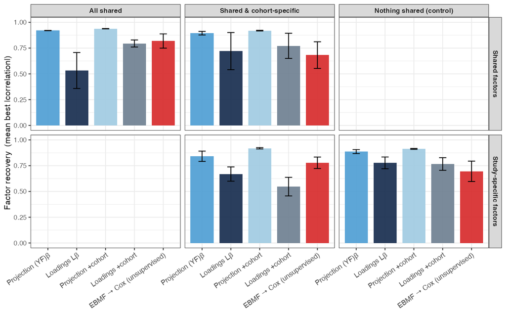

**Figure 1.** Factor recovery = mean best $|$correlation$|$ between each estimated gene program and the true program it matches, by model arm and scenario (mean ± SE over 5 seeds). Top row: shared (prognostic) factors; bottom row: study-specific factors.

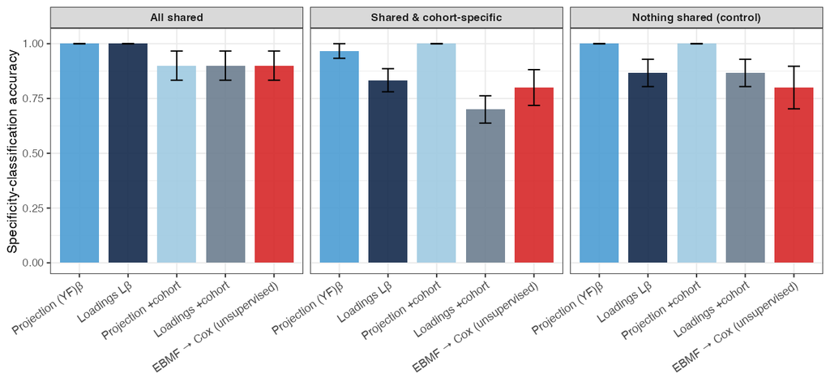

**Figure 2.** Specificity-classification accuracy = fraction of recovered factors correctly *typed* as shared vs. study-specific, from per-cohort loading energy alone (mean ± SE, 5 seeds).

- **Two complementary questions.** Figure 1 asks *how faithfully* each gene program is reconstructed (a correlation); Figure 2 asks whether the model *correctly labels* each program as shared or study-specific (a classification). High recovery with low typing accuracy would mean good programs, wrong structure — so we report both.
- The **projection model** recovers shared factors at $|r|\approx0.90$–$0.92$ and types them with accuracy up to **1.00** — it natively separates shared from study-specific structure, which is *why* the cohort indicator adds little.

## Synthetic Results — Factor Recovery Heatmap

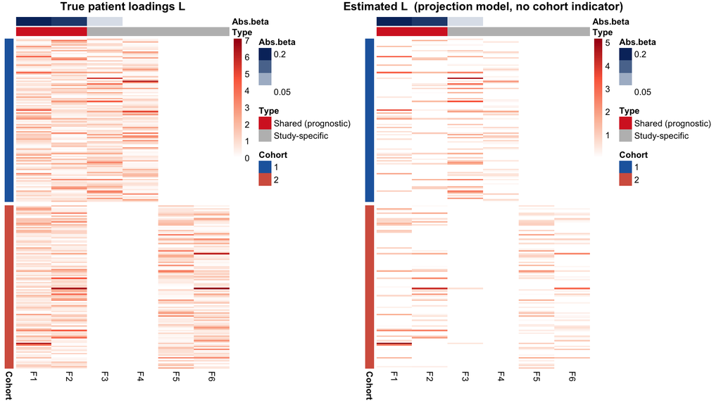

**Figure 3.** Patient-loading matrix $L$ in the realistic *Shared & Cohort-Specific* scenario (hybrid, seed 1). Rows = patients grouped by cohort (left bar); columns = factors. Top annotations: true factor type (shared/prognostic vs. study-specific) and $|\hat\beta|$. **Left:** true block-sparse $L$. **Right:** estimated $L$ from the projection model — recovering shared factors (active in *both* cohorts) and study-specific factors (active in one), with **no cohort indicator**.

- Shared factors light up across **both** cohort blocks; study-specific factors light up in **one** — the model recovers the intended structure directly from the data.

## Synthetic Results — SSBMF outperforms EBMF+Cox

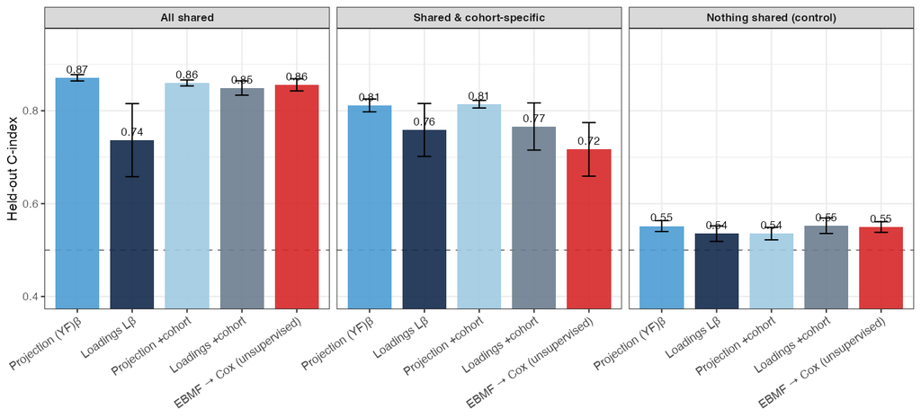

**Figure 4.** Held-out C-index by model arm within each scenario (mean ± SE over 5 seeds; dashed line = chance). The unsupervised EBMF → Cox baseline is shown alongside the supervised arms.

**Hybrid (Shared & Cohort-Specific), mean C-index** (over 5 seeds):

- **Projection $(YF)\beta$: 0.81**
- Loadings $L\beta$: 0.76
- Unsupervised **EBMF → Cox: 0.72**

**Negative control (All Cohort-Specific):** all arms at $\approx 0.54$ — no false prognostic signal manufactured when none exists.

### Takeaway

Joint supervision beats the unsupervised two-step approach on data with known ground truth — and invents no signal when there is none.

## PDAC Cohorts — Prognostic Gene Programs

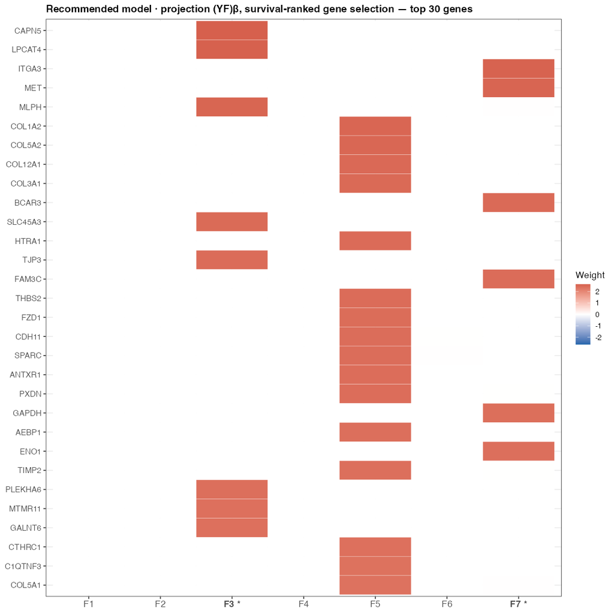

**Figure 5.** Gene-weight heatmap (top 30 genes) for the **recommended model**: projection $(YF)\beta$, per-platform z-standardization, survival-ranked gene selection (2064 genes), **no** cohort indicator, $K=7$. Weights are **non-negative** (point-exponential prior). Survival-active programs ($|\hat\beta|>10^{-3}$) are starred.

- $K=7$ programs **retained** (CV + 1-SE, floor $K\ge3$); **$K_\text{eff}=2$ survival-active** — Program 3 (**protective**) and Program 7 (**adverse**)
- The *largest* expression program (collagen/ECM/stromal) is **not** survival-active — supervision separates expression-only structure from prognostic structure

## PDAC Cohorts — Prognostic Association

The two survival-active programs stratify patients (split at median **projection score $(YF)_k$** — the quantity the model scores on):

- **Adverse — Program 7** (higher activation → shorter survival), log-rank $p=0.00047$
  - top genes: *ITGA3, MET, BCAR3, FAM3C, GAPDH, ENO1, TPI1, PGK1*
- **Protective — Program 3** (higher activation → longer survival), log-rank $p=0.0077$
  - top genes: *CAPN5, LPCAT4, MLPH, SLC45A3, TJP3, PLEKHA6, MTMR11, GALNT6*

Proportional-hazards assumption not violated (Schoenfeld test).

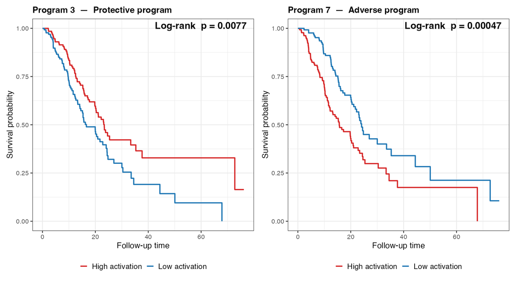

**Figure 6.** Kaplan–Meier curves for the two survival-active programs, patients split at the median projection score $(YF)_k$ in the training cohorts. The adverse program’s high-activation group has worse survival; the protective program’s, better. Direction read empirically from the curves.

## PDAC Cohorts — External C-index

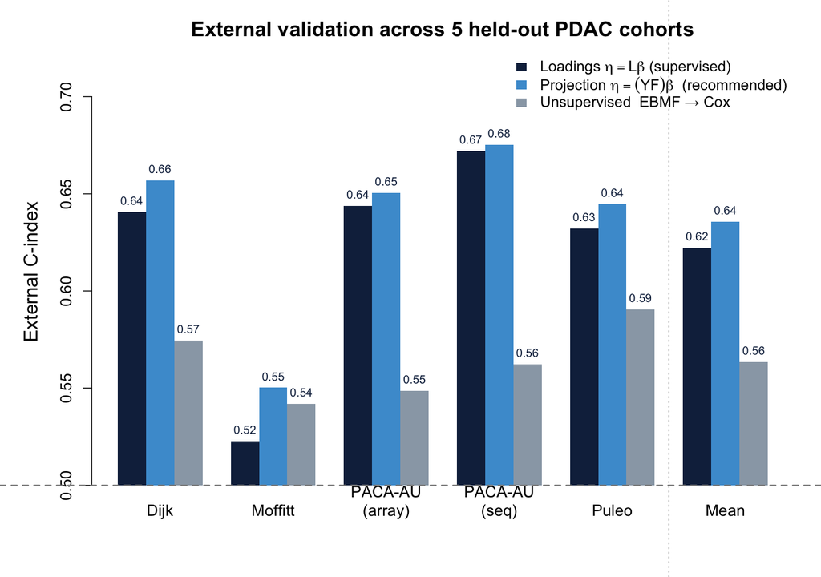

**Figure 7.** External C-index across the five held-out PDAC cohorts (+ mean) for three arms: loadings $L\beta$, projection $(YF)\beta$, and the unsupervised EBMF → Cox two-step. Dashed line = chance.

- **Projection (YFB) model mean C = 0.636** · loadings (LB) model 0.622 · EBMF → Cox 0.564, across the five held-out cohorts
- The projection-based supervised joint model **outperforms the unsupervised two-step approach across all 5 external PDAC cohorts**, with $K=7$ (CV + 1-SE, floor $K\ge3$) $\to K_\text{eff}=2$

## Model Comparison Summary

| Model | Linear predictor | Preprocessing | Cohort ind. | K | K_eff | Synthetic C | Real ext. C |
| --- | --- | --- | --- | --- | --- | --- | --- |
| Projection (recommended) | (YF)β | per-platform z-std + survival-ranked gene selection | no | 7 | 2 | 0.81 | 0.636 |
| Loadings | Lβ | per-platform z-std + survival-ranked gene selection | no | 7 | 2 | 0.76 | 0.622 |
| Projection + cohort ind. | (YF)β | per-platform z-std + survival-ranked gene selection | yes | 8 | 2 | 0.81 | 0.614 |
| Unsupervised two-step | EBMF → Cox | per-platform z-std + survival-ranked gene selection | n/a | 20 | n/a | 0.72 | 0.564 |

Synthetic C = mean held-out C-index, hybrid scenario (5 seeds). Real ext. C = mean across 5 held-out PDAC cohorts. **K** = CV + 1-SE selected (biological floor K≥3); **K_eff** = survival-active programs (|β̂| > 1e-3). Gene selection ranks genes by combined mean × variance per cohort.

- **Recommendation:** projection predictor $(YF)\beta$ · per-platform z-standardization · survival-ranked gene selection · **no** cohort indicator
- Wins on both axes — best synthetic **and** real external C-index — with the most **parsimonious, interpretable** survival structure ($K=7\to K_\text{eff}=2$) and **exact** external scoring

**On gene selection**

The combined-rank selection recipe was **motivated by** the lab’s penalized survival-MF (DeSurv) preprocessing; here it is applied within the fully Bayesian model.

## Impact / key findings

1. **Joint supervision beats the unsupervised two-step** — by ~0.09 C-index on synthetic data with known truth (0.81 vs 0.72, hybrid), and across **all five** held-out PDAC cohorts on real data.
2. **Preprocessing is decisive** — per-platform z-standardization before merging is the difference between a working model and $\beta\to 0$; **10 of 12** alternatives collapse.
3. **Parsimony with signal** — the recommended model carries just **$K_\text{eff}=2$ survival-active programs** (vs ~20 unsupervised factors) yet matches the field, with **exact, leakage-free external scoring**.
4. **Mean external C-index = 0.636** across five independent PDAC cohorts — fully Bayesian throughout (adaptive priors, no $\alpha$ tuning, uncertainty-aware).

### Limitations

- **Small external cohorts give noisy estimates** — per-cohort C ranges down to 0.55 (Moffitt), near chance
- **Real-data margin over unsupervised EBMF → Cox is modest** (EBMF is already ≈0.63 within-training); the *synthetic* gap (0.81 vs 0.72) is the cleaner demonstration of supervision’s value
- The two programs are **statistically** prognostic — **biological annotation (pathway enrichment) is the next step**, not yet done

## Future directions & summary

### Addressed since April

- **CV-based K selection** ✓ — 5-fold CV, 1-SE rule
- **Multi-cohort shared-factor validation** ✓ — completed simulation study

### Next steps

1. **Pathway enrichment** on the two survival-active programs — assign biology to the statistical factors
2. **Manuscript preparation** — methods-primary framing; PDAC as the application

### Summary

1. Joint supervised factorization, two linear predictors; **point-exponential priors on $L,F$, a normal prior on $\beta$**, non-parametric baseline hazard
2. **Preprocessing is crucial** — per-platform normalization prevents the survival precision from being dominated and $\beta$ from collapsing
3. Validated on a completed multi-cohort simulation (hybrid C = 0.81 vs 0.72) **and** five external PDAC cohorts (mean C = 0.636)
4. **Recommended model**
   - Linear predictor: projection $(YF)\beta$
   - L cohort indicator: No
   - Pre-processing: per-platform z-std
   - Selected $K = 7$ ($K_\text{eff} = 2$), mean external C = **0.636**

## Discussion

### Thank You

**Questions, suggestions, and feedback welcome!**

Andrew Walther · awalther@unc.edu

Department of Biostatistics, UNC Gillings School of Global Public Health

# Appendix

## Appendix — cohort-indicator contrast

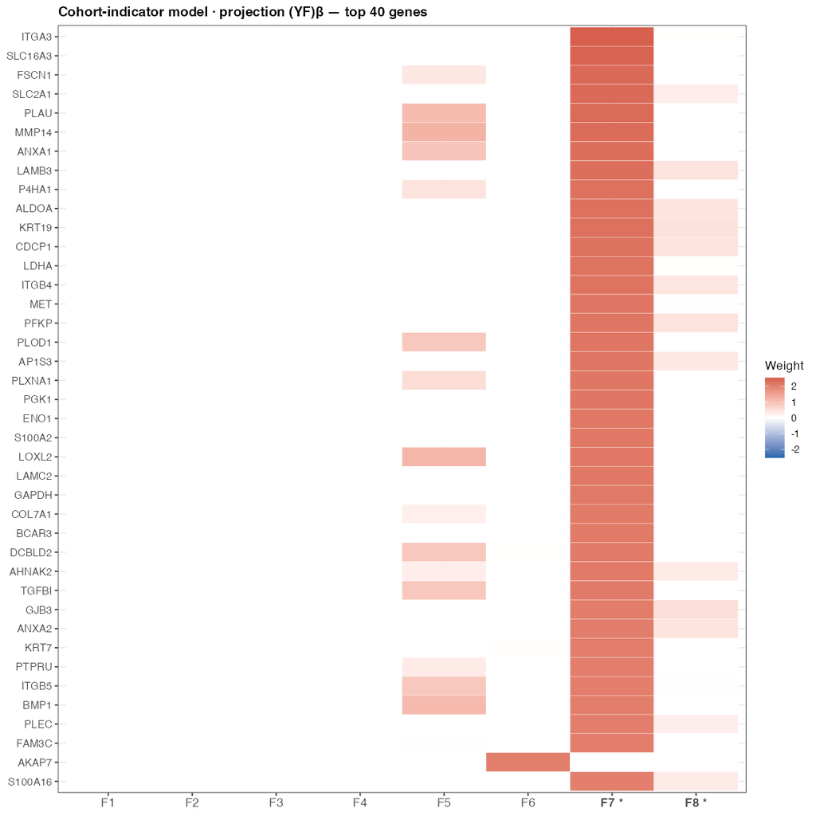

**Figure A1.** Gene-weight heatmap with the cohort-membership indicator added (projection model, $K=8$). Survival-active programs starred.

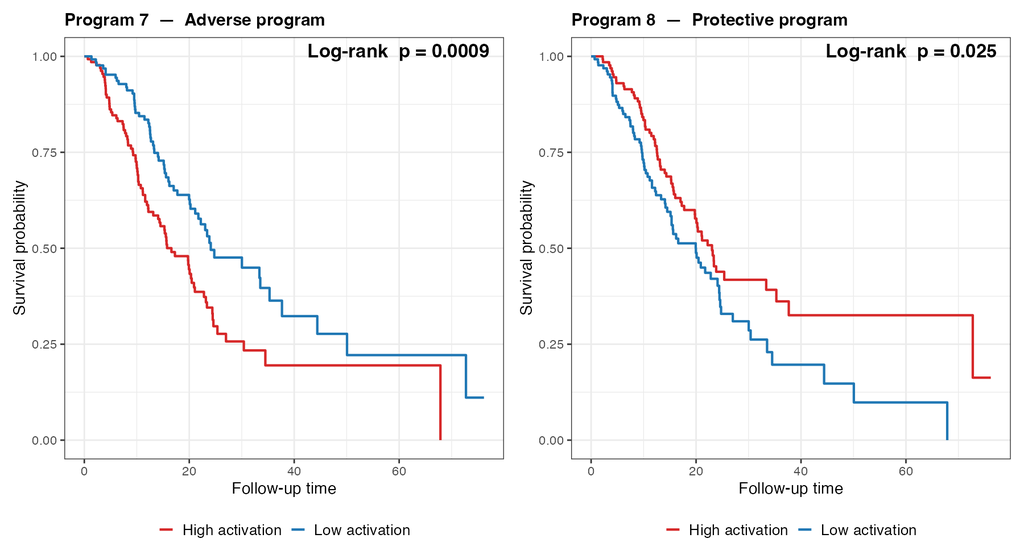

**Figure A2.** Survival stratification with the cohort-membership indicator, by projection score. The survival-active structure is essentially unchanged from the recommended model.

- Adding the indicator under per-platform z-std spends a factor slot ($K:\,7\to8$) **without** improving external C-index (0.636 → 0.614)
- The biological survival-active structure is essentially unchanged — confirming the platform offset is already removed by normalization

## Appendix — convergence & survival-activity magnitudes

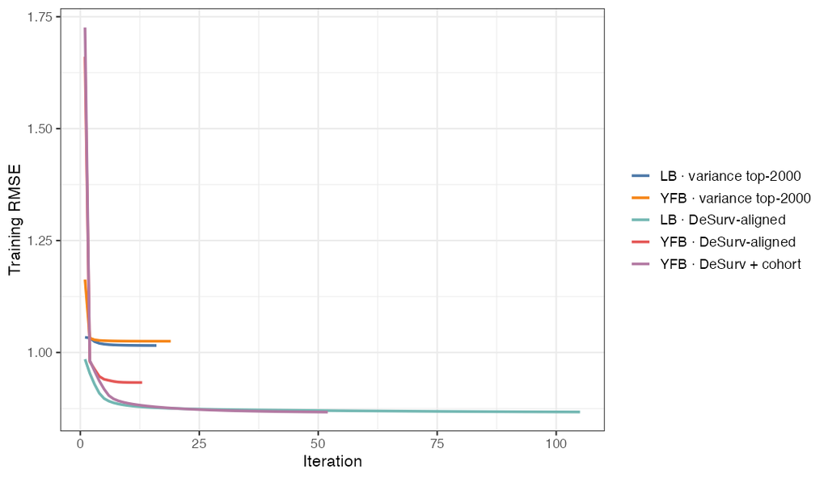

**Figure A3.** Training RMSE convergence traces across model configurations — RMSE stabilizes to a plateau; stopping is governed by the relative ELBO change falling below $10^{-5}$ ($\Delta L,\Delta\beta$ tracked as diagnostics).

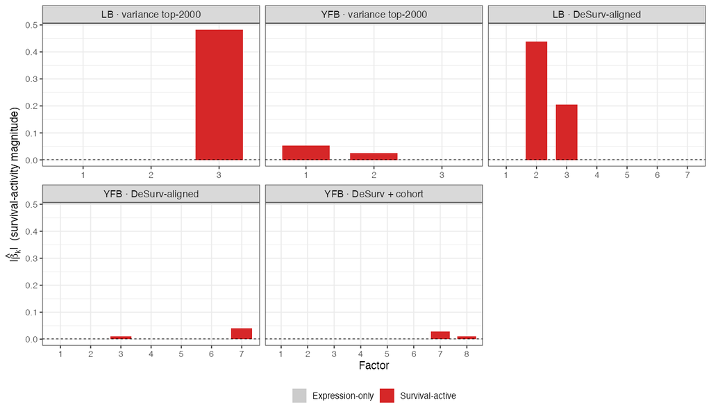

**Figure A4.** Survival-activity magnitude $|\hat\beta_k|$ per program. Most programs fall below the activity threshold (expression-only); a small number clear it (survival-active).

- The spike-and-slab / shrinkage behavior is visible: most programs are shrunk below the survival-activity threshold, with only the survival-active ones retained

## Appendix — relation to DeSurv (Young et al., PNAS 2026)

**Same design & same data — SBMF is the Bayesian counterpart.** Both jointly fit supervised NMF + Cox with **non-negative gene programs**, share the same training set (**TCGA + CPTAC, $n=273$**) and the **same five external PDAC cohorts** (Dijk, Moffitt, PACA-AU array/seq, Puleo; $n=616$), score new patients by **projection** (no retraining), select via **CV C-index + 1-SE**, and use the **combined-rank top-3000-per-cohort** gene selection. Both also find that the **highest-variance program is *not* the most prognostic**.

DeSurv objective: $(1-\alpha)\,\mathcal{L}_\text{NMF} - \alpha\,\mathcal{L}_\text{Cox}$, with the survival gradient on the gene programs $W$.

**What SBMF changes**

|  | DeSurv | SBMF |
| --- | --- | --- |
| Estimation | penalized optimization | Bayesian variational (CAVI) |
| Tuned by BO | $k,\;\alpha,\;\lambda$ | **only $K$** ($\alpha,\lambda$ not tuned) |
| Shrinkage | fixed elastic-net | empirical-Bayes priors (learned) |
| Uncertainty | point estimates | posterior mean **+** variance |
| Noise | least-squares | per-gene precision $\tau$; $E[L^2]$ correction |

- **DeSurv:** $k=3,\ \alpha=0.334$; pooled external **HR/SD $=1.50$** (95% CI 1.31–1.72)
- **SBMF (YF)β:** $K=7\to K_\text{eff}=2$; mean external **C $=0.636**

**Honest caveat:** the two report different primary metrics (DeSurv: pooled HR/SD; SBMF: mean external C-index) and use slightly different normalization (DeSurv within-subject rank → 1970 genes; SBMF per-platform z-std → 2064). A **matched same-protocol head-to-head is a planned next step** — DeSurv is *not* re-run here.

[figure not shown]

Rashid Lab · UNC Chapel Hill